# Descriptive Analytics

# c) Show the percentage of transactions (by transaction volume) by month of the year

```r
Percent_Trans_by_Month<-Online_data %>% group_by(New_Invoice_Month) %>%
  summarise(Percent_of_Trans_by_month=100*(sum(TransactionValue)/sum(Online_data$TransactionValue)))
as.data.frame(Percent_Trans_by_Month)
```

| New_Invoice_Month | Percent_of_Trans_by_month |
| --- | --- |
| 1 | 5.744919 |
| 2 | 5.109515 |
| 3 | 7.009487 |
| 4 | 5.059703 |
| 5 | 7.420519 |
| 6 | 7.090080 |
| 7 | 6.989308 |
| 8 | 7.003469 |
| 9 | 10.460751 |
| 10 | 10.984123 |

[output cut: 2 more lines]

# d)What was the date with the highest number of transactions from Australia?

```r
s1<-filter(Online_data,Country=="Australia") %>% group_by(InvoiceDate) %>%
  summarise(Australia_highest_no_transactions=n())
as.data.frame(s1[which.max(s1$Australia_highest_no_transactions),])
```

| InvoiceDate | Australia_highest_no_transactions |
| --- | --- |
| 6/15/2011 13:37 | 139 |

# e) The company needs to shut down the website for two consecutive hours for maintenance. What would be the hour of the day to start this so that the distribution is at minimum for the customers? The responsible IT team is available from 7:00 to 20:00 every day

```r
# Dataframe with Hour and its corresponding no of transactions per day
distribution<-Online_data %>% group_by(New_Invoice_Hour)%>%
  summarise(No_Of_Transactions=n(),Percentage=100*(n()/nrow(Online_data))) %>%
  filter(New_Invoice_Hour >=7 & New_Invoice_Hour <= 20)
as.data.frame(distribution)
```

| New_Invoice_Hour | No_Of_Transactions | Percentage |
| --- | --- | --- |
| 7 | 383 | 0.07067607 |
| 8 | 8909 | 1.64400296 |
| 9 | 34332 | 6.33538103 |
| 10 | 49037 | 9.04893626 |
| 11 | 57674 | 10.64274629 |
| 12 | 78709 | 14.52439432 |
| 13 | 72259 | 13.33415758 |
| 14 | 67471 | 12.45061440 |
| 15 | 77519 | 14.30480025 |
| 16 | 54516 | 10.05999162 |

[output cut: 4 more lines]

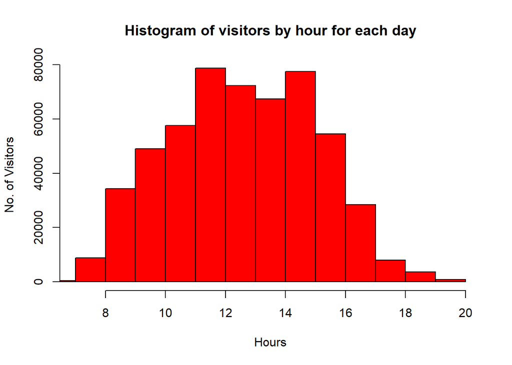

```r
#Plotting a graph to show the website visitors for transactions per hour

hist(Online_data$New_Invoice_Hour,
     main="Histogram of visitors by hour for each day",
     xlim= c(7,20),
     col = "Red",
     xlab = "Hours",
     ylab= "No. of Visitors",
     breaks = 12
     )
```

It is clearly evident that the good time for maintenance shutdown would be 6.00 am and 20:00 pm. As it is mentioned in the question that responsible IT team would be available from 7.00am to 20:00 pm, the best time would be 7.00 am and 20:00 pm as the distribution would be minimum at these hours.

# 5.Plot the histogram of transaction values from Germany. Use the hist() function to plot.

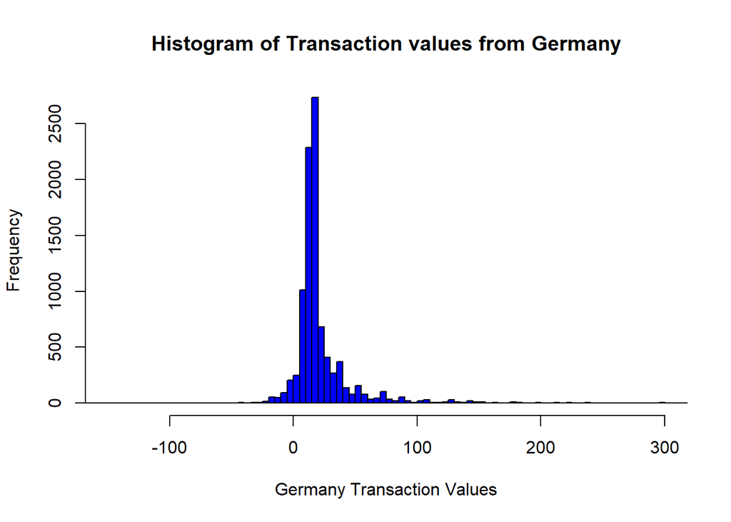

```r
Germany_Transactions<-filter(Online_data,Country=="Germany")
hist(Germany_Transactions$TransactionValue,
     main = "Histogram of Transaction values from Germany",
     col = 'Blue',
     xlab = "Germany Transaction Values",
     ylab="Frequency",
     xlim = c(-150,300),
     breaks=500)
```

# 6. Which customer had the highest number of transactions? Which customer is most valuable (i.e.highest total sum of transactions)?

```r
# Considering the number of transactions to calculate highest number of transactions(valuable customer)
Cust_high_trans_withNA<-Online_data %>%  group_by(CustomerID) %>%
  summarise(Highest_no_of_Trans_with_NAValues=n()) %>% arrange(desc(Highest_no_of_Trans_with_NAValues)) %>% top_n(3)
as.data.frame(Cust_high_trans_withNA)
```

| CustomerID | Highest_no_of_Trans_with_NAValues |
| --- | --- |
| NA | 135080 |
| 17841 | 7983 |
| 14911 | 5903 |

```r
#Omitted NA Values and checked for the valuable customer
Cust_high_trans_without_NA<-Online_data %>% na.omit() %>%
  group_by(CustomerID) %>% summarise(Highest_no_of_Trans=n()) %>% arrange(desc(Highest_no_of_Trans)) %>% top_n(1)
as.data.frame(Cust_high_trans_without_NA)
```

| CustomerID | Highest_no_of_Trans |
| --- | --- |
| 17841 | 7983 |

```r
# Considering the total sum of transactions(Transaction Volume) to calculate highest number of transactions(Valuable Customer)
Cust_high_TransVol_withNA<-Online_data %>% group_by(CustomerID) %>%
  summarise(Highest_Trans_Volume_with_NAValues=sum(TransactionValue)) %>%
  arrange(desc(Highest_Trans_Volume_with_NAValues)) %>% top_n(3)
as.data.frame(Cust_high_TransVol_withNA)
```

| CustomerID | Highest_Trans_Volume_with_NAValues |
| --- | --- |
| NA | 1447682.1 |
| 14646 | 279489.0 |
| 18102 | 256438.5 |

```r
#Omitted NA Values and checked for the valuable customer
Cust_high_TransVol_without_NA <- Online_data %>% na.omit() %>% group_by(CustomerID) %>%
  summarise(Highest_Trans_Volume=sum(TransactionValue)) %>% arrange(desc(Highest_Trans_Volume)) %>% top_n(1)
as.data.frame(Cust_high_TransVol_without_NA)
```

| CustomerID | Highest_Trans_Volume |
| --- | --- |
| 14646 | 279489 |

# 7. Calculate the percentage of missing values for each variable in the dataset

```r
#Percentage of missing values in the dataset
Missing_Values_Percent<-colMeans(is.na(Online_data))
as.data.frame(Missing_Values_Percent)
```

|  | Missing_Values_Percent |
| --- | --- |
| InvoiceNo | 0.0000000 |
| StockCode | 0.0000000 |
| Description | 0.0000000 |
| Quantity | 0.0000000 |
| InvoiceDate | 0.0000000 |
| UnitPrice | 0.0000000 |
| CustomerID | 0.2492669 |
| Country | 0.0000000 |
| TransactionValue | 0.0000000 |
| New_Invoice_Date | 0.0000000 |

[output cut: 3 more lines]

The output data frame shows that CustomerID column has 24.92% of missing values.

# 8. What are the number of transactions with missing CustomerID records by countries?

```r
#No. of transactions with missing CustomerID records by countries
Online_data%>%filter(is.na(Online_data$CustomerID)) %>% group_by(Country) %>%
  summarise(No_of_missing_ID=n()) %>% arrange(desc(No_of_missing_ID))
```

| Country | No_of_missing_ID |
| --- | --- |
| United Kingdom | 133600 |
| EIRE | 711 |
| Hong Kong | 288 |
| Unspecified | 202 |
| Switzerland | 125 |
| France | 66 |
| Israel | 47 |
| Portugal | 39 |
| Bahrain | 2 |

# 9.On average, how often the costumers comeback to the website for their next shopping? (i.e. what is the average number of days between consecutive shopping) . Hint: 1. A close approximation is also acceptable and you may find diff() function useful

```r
Online_data_without_NA<- Online_data %>% na.omit()

Avg_days<-Online_data_without_NA  %>% group_by(CustomerID)%>%
 summarise(LatestPurchase = max(New_Invoice_Date),OldestPurchase= min(New_Invoice_Date), Timediff= (LatestPurchase - OldestPurchase),            AvgDaysBetweenShopping= Timediff/n())
head(Avg_days)
```

| CustomerID | LatestPurchase | OldestPurchase | Timediff | AvgDaysBetweenShopping |
| --- | --- | --- | --- | --- |
| 12346 | 2011-01-18 | 2011-01-18 | 0 days | 0.000000 days |
| 12347 | 2011-12-07 | 2010-12-07 | 365 days | 2.005495 days |
| 12348 | 2011-09-25 | 2010-12-16 | 283 days | 9.129032 days |
| 12349 | 2011-11-21 | 2011-11-21 | 0 days | 0.000000 days |
| 12350 | 2011-02-02 | 2011-02-02 | 0 days | 0.000000 days |
| 12352 | 2011-11-03 | 2011-02-16 | 260 days | 2.736842 days |

```r
mean(Avg_days$Timediff)
```

```
## Time difference of 133.723 days
```

# 10.n the retail sector, it is very important to understand the return rate of the goods purchased by customers.In this example, we can define this quantity, simply, as the ratio of the number of transactions cancelled (regardless of the transaction value) over the total number of transactions. With this definition, what is the return rate for the French customers? Consider the cancelled transactions as those where the ‘Quantity’ variable has a negative value.

```r
#Calculation of return rate for the french customers
France_Transactions<-filter(Online_data,Country=='France')

France_Cancelled_Transactions<-filter(Online_data,Country=='France'& Quantity<0)

Return_rate_France<- (nrow(France_Cancelled_Transactions)/nrow(France_Transactions))*100
print(paste("The return rate for the french customers is :",Return_rate_France))
```

```
## [1] "The return rate for the french customers is : 1.7412644618441"
```

# 11.What is the product that has generated the highest revenue for the retailer? (i.e. item with the highest total sum of ‘TransactionValue’).

```r
#Highest revenue generated by the product for the retailer
High_Revenue<-Online_data %>% group_by(Description) %>% summarise(High_Revenue=sum(TransactionValue)) %>% arrange(desc(High_Revenue)) %>% top_n(1)
as.data.frame(High_Revenue)
```

| Description | High_Revenue |
| --- | --- |
| DOTCOM POSTAGE | 206245.5 |

# 12.How many unique customers are represented in the dataset? You can use unique() and length() functions.

```r
Unique_Customers<-length(unique(Online_data$CustomerID))
print(paste("The number of Unique Customers in the dataset are:",Unique_Customers))
```

```
## [1] "The number of Unique Customers in the dataset are: 4373"
```